# TP1 - Neural Networks from scratch

The architecture of this code is freely inspired from the torch and pytorch architectures, and some sample of code are re-used. It is however designed to be as concise as possible, not in any case for efficiency or flexibility (i.e. if you ever want to do Deep Learning out of this class, don't try to adapt this code, use an existing framework).

Following code allows you to mount your drive in the Colab Virtual Machine in order to get access to the data (skipped if run locally)

```python
try:
  from google.colab import drive
  drive.mount('/content/gdrive', force_remount=True)

  FOLDERNAME = 'DEEPL_TP_1'
  %cd /content/gdrive/My\ Drive/$FOLDERNAME
except ImportError:
  pass
```

## Part 0. A simple Multi-Layer Perceptron (MLP) implementation

As always some useful imports:

```python
import math
import numpy as np
import matplotlib.pyplot as plt
plt.rcParams['image.cmap'] = 'gray'
import scipy.ndimage as ndimage
import scipy.optimize as optimize

import os

try:
    # tqdm is a very useful library to monitor the progression of your loops
    # (not necessary but handy)
    from tqdm.notebook import tqdm
except ImportError:
    pass
```

We will consider a Neural Network as a modular architecture, all layer and loss being a `Module`. We define the `Linear`, `ReLU` layers, necessary to implement a MLP, as well as a simple 2-layer MLP and the meaned square error function, `MSE`.

**Q1.a.** Read carefully the code below, and summarize in a few sentences what is the structure and the purpose of each class.

Module : Abstract class that defines the general structure of every layer(module). It specifies two abstract methods :

```
A forward : computes the output of the module
A backward : computes the gradient and the loss with respect to the module’s inputs.
```

It serves as a parent class for all other components

MSE : Implements the Mean Squared Error loss between predictions and one-hot encoded target labels.

```
  make_target : Builds a one hot encoded target matrix of shape (batch_size, num_classes)
  forward : computes the average square difference between predictions and targets
  backward : computes and returns the gradient of the loss with respect to the model's outputs
```

Linear : A fully connected (dense) layer computing : $ y = xW^T + b $

```
  initialization : creates random weights and zero bias
  forward : computes the linear transformation of the input
  backward : computes gradient with respect to inputs, weights, and biases
  gradientStep : updates weights and biases, by doing a gradient descent with learning rate (1r)
```

ReLU : Implements the Rectified Linear Unit activation function.

```
  forward : replaces all negative values in the input by zero
  backward : propagates the gradient only on positive inputs
```

SimpleMLP : A simple neural network (multi-layer perceptron) whith one hidden layer.

```
  architecture : Linear (in_dimension -> 64) -> RELU -> Linear (64 -> num_classes).
  forward : passes data through each layer sequentially fc1 -> RELU -> fc2
  backward : propagates gradients in reverse order  : fc2 -> RELU -> fc1
  gradient : updates weights and biases of fc1 and fc2
```

```python
class Module(object):
    def __init__(self):
        self.gradInput = None
        self.output = None

    def forward(self, *input):
        """
        Defines the computation performed at every call.
        Should be overriden by all subclasses.
        """
        raise NotImplementedError

    def backward(self, *input):
        """
        Defines the computation performed at every call.
        Should be overriden by all subclasses.
        """
        raise NotImplementedError


class MSE(Module):
    """
    This implementation of the mean squared loss assumes that the data comes as a 2-dimensional array
    of size (batch_size, num_classes) and the labels as a vector of size (batch_size)
    """
    def __init__(self, num_classes=10):
        super(MSE, self).__init__()
        self.num_classes = num_classes

    def make_target(self, x, labels):
        target = np.zeros([x.shape[0], self.num_classes])
        for i in range(x.shape[0]):
            target[i, labels[i]] = 1

        return target

    def forward(self, x, labels):
        target = self.make_target(x, labels)
        self.output = np.sum((target-x)**2, axis=1)
        return np.mean(self.output)

    def backward(self, x, labels):
        target = self.make_target(x, labels)
        self.gradInput = -2*(target - x) / x.shape[0]
        return self.gradInput


class Linear(Module):
    """
    The input is supposed to have two dimensions (batch_size, in_features)
    """
    def __init__(self, in_features, out_features, bias=True):
        super(Linear, self).__init__()
        self.in_features = in_features
        self.out_features = out_features

        std = math.sqrt(2/in_features) # He init because we have ReLU.
        self.weight = std*np.random.randn(out_features, in_features)
        self.bias = np.zeros(out_features)

    def forward(self, x):
        self.output = np.dot(x, self.weight.transpose()) + self.bias[None, :]
        return self.output

    def backward(self, x, gradOutput):
        self.gradInput = np.dot(gradOutput, self.weight)
        self.gradWeight = np.dot(gradOutput.transpose(), x)
        self.gradBias = np.sum(gradOutput, axis=0)
        return self.gradInput

    def gradientStep(self, lr):
        self.weight = self.weight - lr*self.gradWeight
        self.bias = self.bias - lr*self.gradBias


class ReLU(Module):
    def __init__(self, bias=True):
        super(ReLU, self).__init__()

    def forward(self, x):
        self.output = x.clip(0)
        return self.output

    def backward(self, x, gradOutput):
        self.gradInput = (x>0) * gradOutput
        return self.gradInput


class SimpleMLP(Module):
    """
    This class is a simple example of a neural network, composed of two
    linear layers, with a ReLU non-linearity in the middle
    """
    def __init__(self, in_dimension=784, num_classes=10):
        super(SimpleMLP, self).__init__()
        self.fc1 = Linear(in_dimension, 64)
        self.relu1 = ReLU()
        self.fc2 = Linear(64, num_classes)

    def forward(self, x):
        x = self.fc1.forward(x)
        x = self.relu1.forward(x)
        x = self.fc2.forward(x)
        return x

    def backward(self, x, gradient):
        gradient = self.fc2.backward(self.relu1.output, gradient)
        gradient = self.relu1.backward(self.fc1.output, gradient)
        gradient = self.fc1.backward(x, gradient)
        return gradient

    def gradientStep(self, lr):
        self.fc2.gradientStep(lr)
        self.fc1.gradientStep(lr)
```

## Part Ia. Training a neural network

To train a network, we will need data. Download the Mini-MNIST data (~4Mo). It consists of 28×28 images (loaded as vectors of size 784) and the associated label for training and test sets.

```
n_train=9000, n_val=1000, n_test=2000
5
```

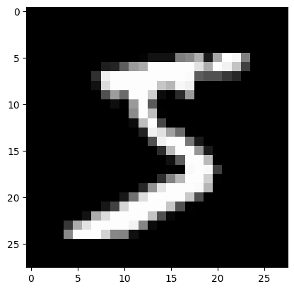

```python
data = np.load("mini_mnist.npz")

train_data = data["train_data"]
train_labels = data["train_labels"]
test_data = data["test_data"]
test_labels = data["test_labels"]

N_val = int(0.1 * len(train_data))
val_data = train_data[-N_val:]
val_labels = train_labels[-N_val:]

N_train = len(train_data) - N_val
train_data = train_data[:N_train]
train_labels = train_labels[:N_train]

N_test = test_data.shape[0]

print(f'n_train={N_train}, n_val={N_val}, n_test={N_test}')

# Check that data makes sense
plt.figure()
plt.imshow(train_data[0, :].reshape(28,28))
print(train_labels[0])
plt.show()
```

**Q1.b.** Read and understand the code above and explain in a few words why we need to split data in {train, val, test}

If we don't split data in {train, val, test} and only train the model on the entire dataset, the model will likely overfit and we won’t be able to evaluate its real performance.

Splitting the data allows us to test the model, on unseen data. which gives a more reliable estimate of how it will perform on new data.

The train set is used to learn the parameters of the model

The validation test is used to monitor overfitting during training and tune hyperparameters.

The Test set is used only once, at the end, to evaluate the final model on a fully unseen dataset.

**Q2.** Plot a grid of 5x5 images showing the first 25 samples of the dataset with associated labels

*Help*:

- execute `?function` to get the doc of a function
- instanciation of a figure can be done with `fig, axes = plt.subplot(n_row, n_col, figsize=(width, height))`, where `fig` is a Figure and `axes` is a 2D array of Axes
- access an axis element through `axes[i][j]`
- given an axis element `ax`, plot image with `ax.imshow` and add a title with `ax.set_title`

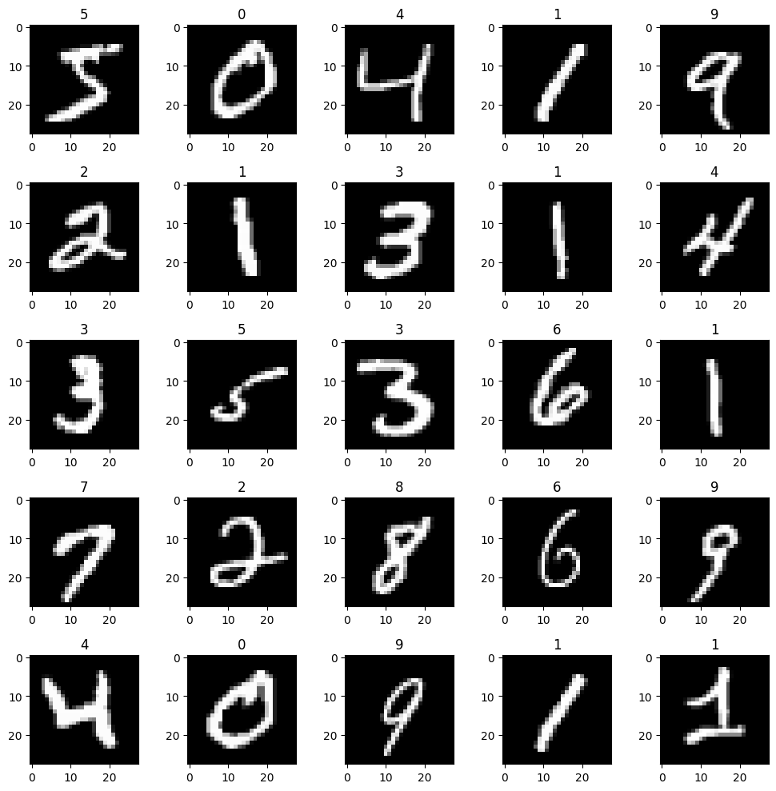

```python
fig, axes = plt.subplots(5, 5, figsize=(10, 10))
for i in range(5):
    for j in range(5):
        axes[i][j].imshow(train_data[i*5+j].reshape(28,28))
        axes[i][j].set_title(train_labels[i*5+j])
plt.tight_layout()
plt.show()
```

**Q3.a.** Write a function `train_iter(model, loss, batch_data, batch_labels, lr)` that performs one iteration of gradient descent given `model` and `loss` (subclasses of `Module`) on a batch `(batch_data, batch_labels)` with a learning rate `lr`, and returns the training loss value.

*Help:*

1. Make the predictions (`model.forward`)
2. Compute the loss between the predictions and the labels (`loss.forward`)
3. Compute its gradient wrt the predictions and the labels (`loss.backward`)
4. Backpropagate the gradient into the model (`model.backward`)
5. Perform gradient descent (`model.gradientStep`)

```python
#We follow upper procedure for training :

def train_iter(model, loss, batch_data, batch_labels, lr):
    """ Performs one iteration of gradient descent on the model"""
    predictions = model.forward(batch_data)
    loss_value = loss.forward(predictions, batch_labels)
    gradient = loss.backward(predictions, batch_labels)
    model.backward(batch_data,gradient)
    model.gradientStep(lr)
    return loss_value
```

**Q3.b.** Test your function. Write a simple loop that trains for 1 epoch a `SimpleMLP` using `MSE` loss on `train_data` with a learning rate of `1e-2` and batches of size `16`. You will print the loss every 10 iterations. To avoid overfitting, the training data should be shuffled before entering any new epoch.

*Note:* An **iteration** consists in running one batch of samples through the model; an **epoch** consists in running multiple iterations so that to process all the samples once.

*Help:* `np.random.shuffle` shuffles the content of an array inplace

```python
lr = 1e-2
batch_size = 16
model = SimpleMLP()
loss = MSE()

indices = np.arange(N_train)
np.random.shuffle(indices) # Shuffle indices to have the same shuffle on both data and labels
train_data = train_data[indices]
train_labels = train_labels[indices]

for i in range(N_train // batch_size):
    batch_data = train_data[i * batch_size:(i + 1) * batch_size]
    batch_labels = train_labels[i * batch_size:(i + 1) * batch_size]

    loss_value = train_iter(model, loss, batch_data, batch_labels, lr)

    if i % 10 == 0: # Print every 10 iterations
        print(f"Epoch {1}, iteration {i}, loss {loss_value:.4f}")
```

```
Epoch 1, iteration 0, loss 2.8487
Epoch 1, iteration 10, loss 1.2096
Epoch 1, iteration 20, loss 0.9363
Epoch 1, iteration 30, loss 0.9166
Epoch 1, iteration 40, loss 0.8034
Epoch 1, iteration 50, loss 0.8841
Epoch 1, iteration 60, loss 0.7517
Epoch 1, iteration 70, loss 0.7878
Epoch 1, iteration 80, loss 0.7084
Epoch 1, iteration 90, loss 0.7784
Epoch 1, iteration 100, loss 0.7594
Epoch 1, iteration 110, loss 0.7461
Epoch 1, iteration 120, loss 0.6221
Epoch 1, iteration 130, loss 0.7769
Epoch 1, iteration 140, loss 0.6266
Epoch 1, iteration 150, loss 0.5657
Epoch 1, iteration 160, loss 0.5779
Epoch 1, iteration 170, loss 0.6804
Epoch 1, iteration 180, loss 0.5891
Epoch 1, iteration 190, loss 0.6275
Epoch 1, iteration 200, loss 0.6086
Epoch 1, iteration 210, loss 0.5257
Epoch 1, iteration 220, loss 0.5638
Epoch 1, iteration 230, loss 0.4989
Epoch 1, iteration 240, loss 0.4773
Epoch 1, iteration 250, loss 0.5425
Epoch 1, iteration 260, loss 0.4754
Epoch 1, iteration 270, loss 0.6040
Epoch 1, iteration 280, loss 0.4550
Epoch 1, iteration 290, loss 0.5008
Epoch 1, iteration 300, loss 0.6552
Epoch 1, iteration 310, loss 0.4873
Epoch 1, iteration 320, loss 0.5656
Epoch 1, iteration 330, loss 0.5259
Epoch 1, iteration 340, loss 0.5624
Epoch 1, iteration 350, loss 0.6141
Epoch 1, iteration 360, loss 0.5267
Epoch 1, iteration 370, loss 0.3650
Epoch 1, iteration 380, loss 0.5619
Epoch 1, iteration 390, loss 0.4100
Epoch 1, iteration 400, loss 0.4038
Epoch 1, iteration 410, loss 0.4532
Epoch 1, iteration 420, loss 0.4460
Epoch 1, iteration 430, loss 0.4494
Epoch 1, iteration 440, loss 0.5150
Epoch 1, iteration 450, loss 0.5367
Epoch 1, iteration 460, loss 0.4420
Epoch 1, iteration 470, loss 0.3993
Epoch 1, iteration 480, loss 0.4248
Epoch 1, iteration 490, loss 0.5041
Epoch 1, iteration 500, loss 0.5868
Epoch 1, iteration 510, loss 0.5129
Epoch 1, iteration 520, loss 0.4788
Epoch 1, iteration 530, loss 0.3960
Epoch 1, iteration 540, loss 0.4967
Epoch 1, iteration 550, loss 0.4140
Epoch 1, iteration 560, loss 0.4540
```

**Q4.a.** Write a function `evaluate(model, loss, data, labels)` that returns a couple `(loss, accuracy)` corresponding to the loss and accuracy computed on some `data`.

*NB:* `for` loops are so slow, avoid them as much as possible!

```python
def evaluate(model, loss, data, labels):
    """ Evaluate the model on the given data and labels
        Returns the couple (loss,accuracy)
    """
    predictions = model.forward(data)
    loss_value = loss.forward(predictions, labels)
    predictions = np.argmax(predictions, axis=1) # Convert to class predictions
    accuracy = np.mean(predictions == labels) # Expectation of correct predictions
    return loss_value, accuracy
```

**Q4.b.** Use your function to evaluate the model trained in **Q3.b.** on the validation data.

```python
val_loss, val_accuracy = evaluate(model, loss, val_data, val_labels)
print(f'Validation loss {val_loss}, accuracy {val_accuracy}')
```

```
Validation loss 0.42177543237488196, accuracy 0.835
```

**Q4.c.** Check visually the quality of the results by plotting 25 validation examples and their predictions.

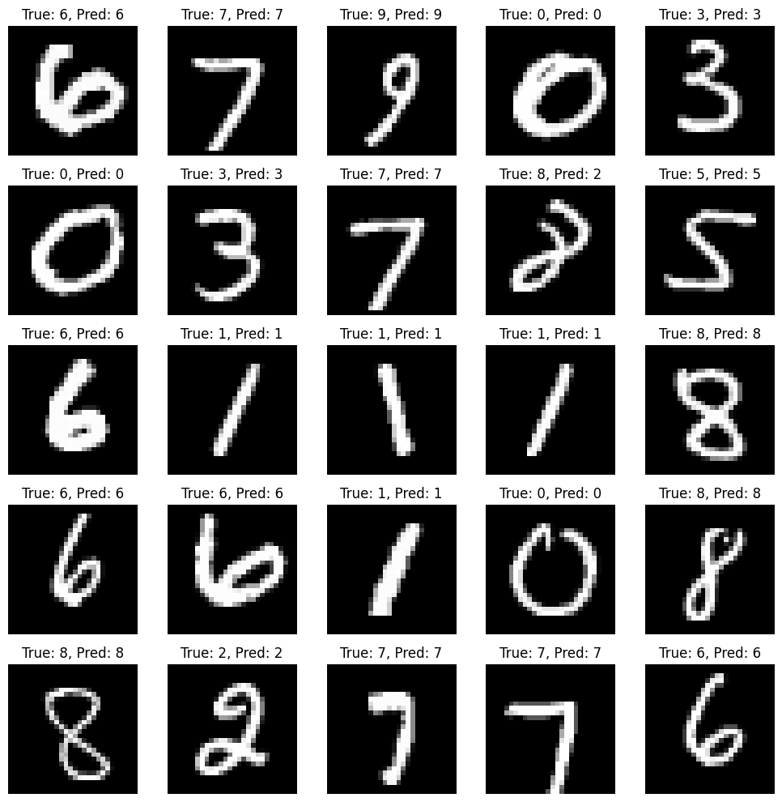

```python
predictions = model.forward(val_data)
predictions = np.argmax(predictions, axis=1)

fig,axes = plt.subplots(5,5,figsize=(10,10))
for i in range(5):
    for j in range(5):
        axes[i][j].imshow(val_data[i*5+j].reshape(28,28))
        axes[i][j].set_title(f'True: {val_labels[i*5+j]}, Pred: {predictions[i*5+j]}')
        axes[i][j].axis('off')
plt.tight_layout()
plt.show()
```

**Q4.d.** Make a failure case analysis on the full validation data using (i) a bar plot showing the percentage of error for each class and (ii) the prediction distribution over the classes for some failure cases. Comment briefly.

*Help:*

- `plt.bar` can be used to do a barplot
- `np.unique` is useful to compute unique elements in an array as well as respective count

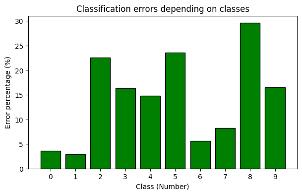

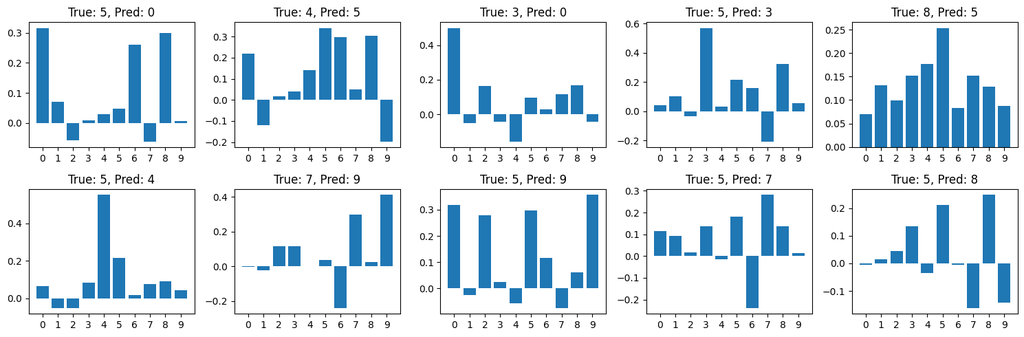

```python
predictions = model.forward(val_data)
predicted_labels = np.argmax(predictions, axis=1)

error_rates = []

for i in range(10):
  mask = (val_labels == i)
  total = np.sum(mask)
  if total == 0:
      error_rates.append(0)
      continue
  errors = np.sum(predicted_labels[mask] != val_labels[mask])
  error_rate = 100 * errors / total
  error_rates.append(error_rate)

plt.figure(figsize=(7,4))
plt.bar(range(10), error_rates, color='green', edgecolor='black')
plt.xlabel('Class (Number)')
plt.ylabel('Error percentage (%)')
plt.title('Classification errors depending on classes')
plt.xticks(range(10))
plt.show()

wrong_idx = np.where(predicted_labels != val_labels)[0]

plt.figure(figsize=(15, 5))
for i, idx in enumerate(np.random.choice(wrong_idx, 10, replace=False)):
    plt.subplot(2,5,i+1)
    plt.bar(range(10),predictions[idx])
    plt.title(f"True: {val_labels[idx]}, Pred: {predicted_labels[idx]}")
    plt.xticks(range(10))
plt.tight_layout()
plt.show()
```

## Part Ib. Training a neural network

**Q5.a.** Write a `train_epoch(model, loss, data, labels, val_data, val_labels, lr, batch_size)` function that trains a model for a whole epoch and returns train and val losses as well as accuracies on validation every 10 iterations (do not print anything during trainin this time). Test it to train a `SimpleMLP` from scratch for 2 epochs with the same parameters as in question **3.b.**

```python
def train_epoch(model, loss, data, labels, val_data, val_labels, lr, batch_size):
    train_losses = []
    val_losses = []
    val_accuracies = []

    indices = np.arange(len(data))
    np.random.shuffle(indices)
    data = data[indices]
    labels = labels[indices]

    for i in range(len(data) // batch_size):
        batch_data = data[i * batch_size:(i + 1) * batch_size] #Take the batch data
        batch_labels = labels[i * batch_size:(i + 1) * batch_size]

        loss_value = train_iter(model, loss, batch_data, batch_labels, lr) #Train the model on the batch

        # Evaluation every 10 batches
        if i % 10 == 0:
            val_loss, val_accuracy = evaluate(model, loss, val_data, val_labels)
            train_losses.append(loss_value)
            val_losses.append(val_loss)
            val_accuracies.append(val_accuracy)

    return train_losses, val_losses, val_accuracies

lr = 1e-2
batch_size = 16
model = SimpleMLP()
loss = MSE()

train_losses_1, val_losses_1, val_accuracies_1 = train_epoch(model, loss, train_data, train_labels, val_data, val_labels, lr, batch_size)
train_losses_2, val_losses_2, val_accuracies_2 = train_epoch(model, loss, train_data, train_labels, val_data, val_labels, lr, batch_size)

train_losses = train_losses_1 + train_losses_2 # Concatenate the losses from both epochs
val_losses = val_losses_1 + val_losses_2 # Concatenate the losses from both epochs
val_accuracies = val_accuracies_1 + val_accuracies_2 # Concatenate the accuracies from both epochs
```

**Q5.b.** Plot train+val losses as well as the accuracy on the validation as a function of the number of iterations. Choose nice colors and add legends to ease the reading.

*Help:* you can simply use `plt.plot`

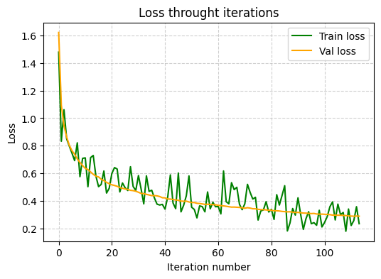

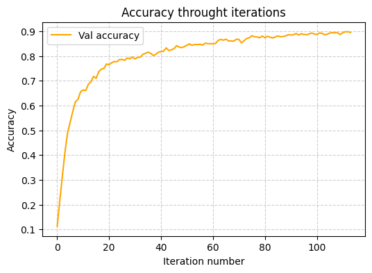

```python
plt.figure(figsize=(6,4))
plt.plot(range(len(train_losses)),train_losses,color ='green', label='Train loss')
plt.plot(range(len(val_losses)),val_losses,color ='orange', label='Val loss')
plt.xlabel('Iteration number')
plt.ylabel('Loss')
plt.title('Loss throught iterations')
plt.legend()
plt.grid(True, linestyle='--', alpha=0.6)
plt.show()

plt.figure(figsize=(6,4))
plt.plot(range(len(val_accuracies)),val_accuracies, color='orange', label='Val accuracy')
plt.xlabel('Iteration number')
plt.ylabel('Accuracy')
plt.title('Accuracy throught iterations')
plt.legend()
plt.grid(True, linestyle='--', alpha=0.6)
plt.show()
```

**Q6.a.** Based on the previous questions, design a function

```
train(model, loss, train_data, train_labels, val_data, val_labels, ...)
```

that performs a full training of the input `model` on the training data. Choose the arguments of your function (for instance, `batch_size`, `lr`, `epochs`, etc) according to what seems relevant to you. This function should plot at the end the evolution of train / val losses and accuracies.

```python
def train(model, loss, train_data, train_labels, val_data, val_labels, lr, batch_size, epochs):
  train_losses = []
  val_losses = []
  val_accuracies = []
  for epoch in range(epochs):
    train_epoch_losses, val_epoch_losses, val_epoch_accuracies = train_epoch(model, loss, train_data, train_labels, val_data, val_labels, lr, batch_size)
    train_losses.extend(train_epoch_losses)
    val_losses.extend(val_epoch_losses)
    val_accuracies.extend(val_epoch_accuracies)

  plt.figure(figsize=(6,4))
  plt.plot(range(len(train_losses)),train_losses,color ='green', label='Train loss')
  plt.plot(range(len(val_losses)),val_losses, color = 'orange', label='Val loss')
  plt.xlabel('Iteration number')
  plt.ylabel('Loss')
  plt.title('Loss throught iterations')
  plt.legend()
  plt.grid(True, linestyle='--', alpha=0.6)
  plt.show()

  plt.figure(figsize=(6,4))
  plt.plot(range(len(val_accuracies)),val_accuracies,color = 'orange', label='Val accuracy')
  plt.xlabel('Iteration number')
  plt.ylabel('Accuracy')
  plt.title('Accuracy throught iterations')
  plt.legend()
  plt.grid(True, linestyle='--', alpha=0.6)
  plt.show()

  print('Final results after training:')
  print(f'Final train loss: {train_losses[-1]:.3f}, final val loss: {val_losses[-1]:.3f}')
  print(f'final val accuracy: {val_accuracies[-1]:.3f}')

  return train_losses, val_losses, val_accuracies
```

**Q6.b.** Use your function to train a model with a good accuracy (decide for a epoch, learning rate, batch size...)

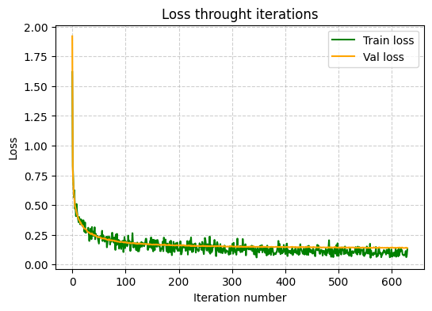

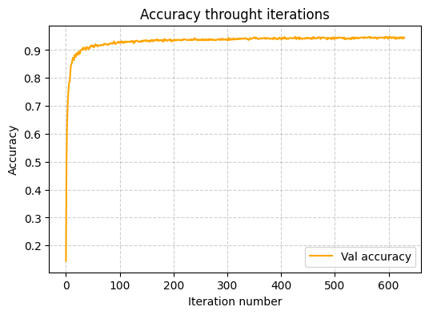

```
Final results after training:
Final train loss: 0.129, final val loss: 0.139
final val accuracy: 0.944
```

```python
model = SimpleMLP()
loss = MSE()
lr = 1e-2*5 # An explanation of the choice of hyperparameters is given in Q.9
batch_size = 50
epochs = 35
train_losses, val_losses, val_accuracies = train(model, loss, train_data, train_labels, val_data, val_labels, lr, batch_size, epochs)
```

## Part II. Overfitting

**Q7.** What's the number of parameters in the network `SimpleMLP` used in the first section?

The first layer has dimensions 784 -> 64. Including the bias, it has 784 × 64 + 64 = 50,240 parameters.

The second layer has dimensions 64 -> 10. Including the bias, it has 64 × 10 + 10 = 650 parameters.

Thus, the total number of parameters in the SimpleMLP network from the first section is 50,240 + 650 = 50,890.

**Q8.a.** Rewrite the definition of `SimpleMLP` to allow changing the dimension of the hidden layer. Test it by training 1 epoch with 128 hidden features and plotting its performances.

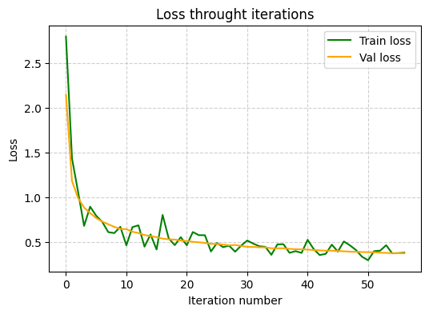

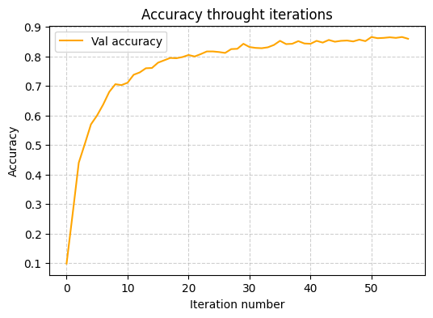

```
Final results after training:
Final train loss: 0.380, final val loss: 0.372
final val accuracy: 0.860
```

```python
class SimpleMLP(Module):
    """
    This class is a simple example of a neural network, composed of two
    linear layers, with a ReLU non-linearity in the middle
    """
    def __init__(self,hidden_feature=64, in_dimension=784, num_classes=10):
        super(SimpleMLP, self).__init__()
        self.fc1 = Linear(in_dimension, hidden_feature)
        self.relu1 = ReLU()
        self.fc2 = Linear(hidden_feature, num_classes)

    def forward(self, x):
        x = self.fc1.forward(x)
        x = self.relu1.forward(x)
        x = self.fc2.forward(x)
        return x

    def backward(self, x, gradient):
        gradient = self.fc2.backward(self.relu1.output, gradient)
        gradient = self.relu1.backward(self.fc1.output, gradient)
        gradient = self.fc1.backward(x, gradient)
        return gradient

    def gradientStep(self, lr):
        self.fc2.gradientStep(lr)
        self.fc1.gradientStep(lr)


model = SimpleMLP(128)
loss = MSE()
lr = 1e-2
batch_size = 16
epochs = 1
train_losses, val_losses, val_accuracies = train(model, loss, train_data, train_labels, val_data, val_labels, lr, batch_size, epochs)
```

The final val accuracy of a SimpleMLP(128) is a little bit better than a SimpleMLP(64) when both are trained on one epoch. However, its potential is way better and its accuracy could increase with longer training.

**Q8.b.** Define a class `DoubleMLP` with three `Linear` layers and parameters to change their dimensions. Test it by training 1 epoch with [64, 32] hidden features and plotting its performances. Does it look better than `SimpleMLP`so far?

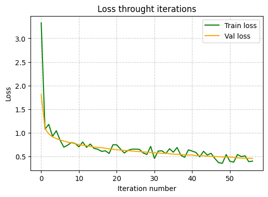

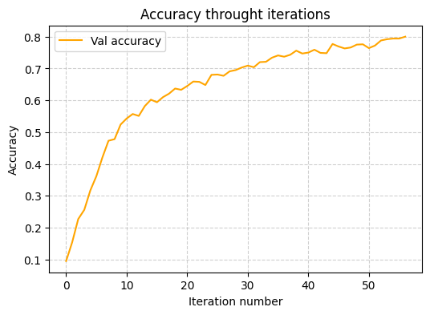

```
Final results after training:
Final train loss: 0.401, final val loss: 0.457
final val accuracy: 0.800
```

```python
class DoubleMLP(Module):
    """
    This class is a simple example of a neural network, composed of three
    linear layers, with a ReLU non-linearity in the middle
    """
    def __init__(self, hidden_feature_1=64, hidden_feature_2=64, in_dimension=784, num_classes=10):
        super(DoubleMLP, self).__init__()
        self.fc1 = Linear(in_dimension, hidden_feature_1)
        self.relu1 = ReLU()
        self.fc2 = Linear(hidden_feature_1, hidden_feature_2)
        self.relu2 = ReLU()
        self.fc3 = Linear(hidden_feature_2, num_classes)


    def forward(self, x):
        x = self.fc1.forward(x)
        x = self.relu1.forward(x)
        x = self.fc2.forward(x)
        x = self.relu2.forward(x)
        x = self.fc3.forward(x)
        return x

    def backward(self, x, gradient):
        gradient = self.fc3.backward(self.relu2.output, gradient)
        gradient = self.relu2.backward(self.fc2.output, gradient)
        gradient = self.fc2.backward(self.relu1.output, gradient)
        gradient = self.relu1.backward(self.fc1.output, gradient)
        gradient = self.fc1.backward(x, gradient)
        return gradient

    def gradientStep(self, lr):
        self.fc3.gradientStep(lr)
        self.fc2.gradientStep(lr)
        self.fc1.gradientStep(lr)


model = DoubleMLP(64,32)
loss = MSE()
lr = 1e-2
batch_size = 16
epochs = 1
train_losses, val_losses, val_accuracies = train(model, loss, train_data, train_labels, val_data, val_labels, lr, batch_size, epochs)
```

(Values may vary due to randomness.)

Thus, it seems that the DoubleMLP performs slightly worse so far. However, by analyzing the loss and accuracy over the iterations, it appears that the DoubleMLP has not been trained long enough to reach its best results. At the end of the epoch, the accuracy still seems to be increasing, which is not the case for the SimpleMLP. This behavior is consistent with the fact that the DoubleMLP model has a more complex architecture and therefore requires more training.

We then plot the evolution of the training accuracy and loss for the same DoubleMLP over 2 epochs.

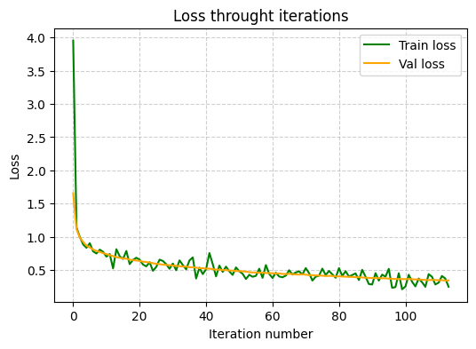

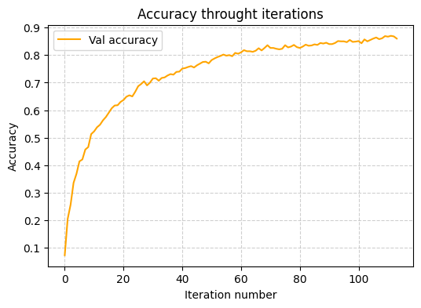

```
Final results after training:
Final train loss: 0.250, final val loss: 0.346
final val accuracy: 0.860
```

```python
model = DoubleMLP(64,32)
loss = MSE()
lr = 1e-2
batch_size = 16
epochs = 2
train_losses, val_losses, val_accuracies = train(model, loss, train_data, train_labels, val_data, val_labels, lr, batch_size, epochs)
```

As expected, the accuracy (resp loss) increases (resp decreases) significatively with more epochs.

**Q8.c.** Define a class `DeepMLP` with a **list** parameter `hidden_features` that allows to vary the number of intermediate linear layers, and their dimensions:

- `DeepMLP([64])` should be equivalent to `SimpleMLP()`;
- `DeepMLP([64, 64, 64])` should be a MLP with four linear layers...

Test it by training 1 epoch with [64, 64, 32] hidden features and plotting its performances.

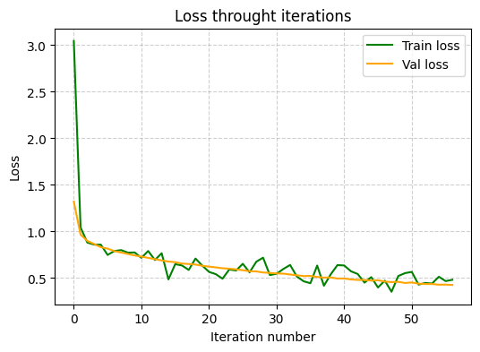

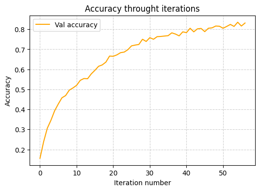

```
Final results after training:
Final train loss: 0.481, final val loss: 0.426
final val accuracy: 0.831
```

```python
class DeepMLP (Module):
    """
    This class is a simple example of a neural network, composed of
    linear layers, with a ReLU non-linearity
    """
    def __init__(self, hidden_features, in_dimension=784, num_classes=10):
        super(DeepMLP, self).__init__()
        self.layers = [] # Layers are now listed in a list
        self.activations = [] # Activations are now listed in a list

        prev_dim = in_dimension # Parameter to ensure right dimensions for the layers
        for h in hidden_features:
            self.layers.append(Linear(prev_dim, h))
            self.activations.append(ReLU())
            prev_dim = h

        self.layers.append(Linear(prev_dim, num_classes))

    def forward(self, x):
            self.inputs = [x]
            for i in range(len(self.layers)): # Iteration over layers
                x = self.layers[i].forward(x)
                if i < len(self.activations):
                    x = self.activations[i].forward(x)
                self.inputs.append(x)
            return x

    def backward(self, x, gradient):
        for i in range(len(self.layers) - 1, -1, -1): # Iteration over layers in reverse order
            if i < len(self.activations):
                gradient = self.activations[i].backward(self.layers[i].output, gradient)
            gradient = self.layers[i].backward(
                self.inputs[i], gradient
            )
        return gradient

    def gradientStep(self, lr): # Iteration of gradient step over all layers
        for i in range(len(self.layers)):
            self.layers[i].gradientStep(lr)


model = DeepMLP([64,64,32])
loss = MSE()
lr = 1e-2
batch_size = 16
epochs = 1
train_losses, val_losses, val_accuracies = train(model, loss, train_data, train_labels, val_data, val_labels, lr, batch_size, epochs)
```

Here the same problem in the 8.b occurs. This model lack of training in order to give good results

**Q9.** Benchmark / analyse some of the components introduced e.g. model structure (depth ie number of layers or width ie number of hidden features), batch size, learning rate, etc. by running full training and evaluating on the validation split.

Once you are happy with your final model, print the score obtained on the test data.

Analysis of hyperparameters :

We experimented with various hyperparameter configurations, analyzed them, and tried to explain their impact on model accuracy.

Testing different configurations suggests that the model performs better with large dimensions in the first layers, which capture the 784 inputs more effectively. However, smaller sizes in the last layer are more efficient. To recognize different digits, we can expect that the last layer of our model captures large patterns in the drawing and associates them with specific numbers. As shown in this lecture video (https://www.3blue1brown.com/lessons/gradient-descent), this hypothesis is not entirely realistic—especially for an MLP, which does not capture spatial patterns—and the real behavior of the system seems non-intuitive to humans. However, even if the patterns recognized by the model are not interpretable by humans, the hypothesis that only a limited number of such patterns (and therefore fewer neurons in the last layer) are needed seems relevant. Besides, using more layer increases a lot the computational cost whithout improving the accuracy.

lr: The learning rate affects a lot the efficiency of the model. A too low learning rate (around 1e-3) slow down convergence, whereas a large lr (greater than 1e-1) causes the loss to diverge. Thus, by testing different values, an lr as high as possible (without divergence) is optimal. We can see that this observation follows the advice in lecture 1:

```
“The most common strategy is to pick a high learning rate that still leads to steady loss decrease and keep it constant until convergence” (handout p.18).
```

This enables the model to escape local minima during training. The next step, explained in the lecture, would be to train the model again with a lower lr to converge to a more precise minimum. Thus, we can expect better results with a controlled learning rate during training. Althought, here, in practice a second training doesn't improve results a lot.

batch_size: The batch size controls the level of stochasticity during training and is limited by the dataset size. A small batch size greatly increases the computational cost of the training since each epoch takes more iterations. However, larger batch sizes require more epochs to reach same accurracies. In the lecture, it is recommended to use large batch sizes (while still much smaller than the dataset size). In practice batch_size around 100 tends to give better results

epochs: Epochs really depend on the other hyperparameter values, but in practice, more epochs enable the model to fully converge. However, too many epochs lead to overfitting, which can be observed by the gap between training and validation loss. To obtain better results, the number of epochs should be tuned to enable convergence without too much overfitting.

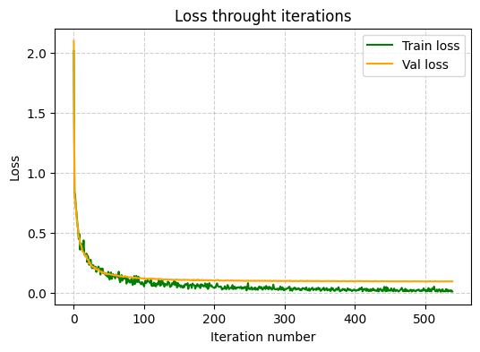

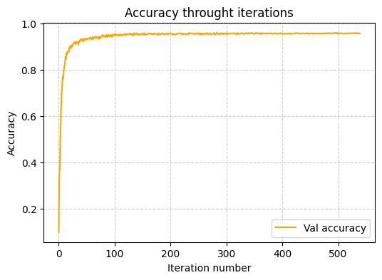

```
Final results after training:
Final train loss: 0.010, final val loss: 0.094
final val accuracy: 0.956
```

```python
model = DeepMLP([128,128,32])
loss = MSE()
lr = 1 * 1e-1
batch_size = 100
epochs = 60
train_losses, val_losses, val_accuracies = train(model, loss, train_data, train_labels, val_data, val_labels, lr, batch_size, epochs)
```

```python
# We now try the model on the test set
test_loss, test_accuracy = evaluate(model, loss, test_data, test_labels)
print(f'Test loss {test_loss}, accuracy {test_accuracy}')
```

```
Test loss 0.11962808853255633, accuracy 0.939
```

## Part III. Going further

The following questions do not have a specific order, a limited number of bonus points can be granted on completing them.

**Q10.** Implement and test different non-linearities (Sigmoid, LeakyReLU, Tanh)

```python
# We first modify the DeepMLP class to use it with different non-linearities

class DeepMLP (Module):
    """
    This class is a simple example of a neural network, composed of
    linear layers, with a non-linearity function
    """
    def __init__(self, hidden_features,non_linearity_function=ReLU, in_dimension=784, num_classes=10): # We add a parameter to choose the non-linearity function
        super(DeepMLP, self).__init__()
        self.layers = []
        self.activations = []
        self.non_linearity_function = non_linearity_function

        prev_dim = in_dimension
        for h in hidden_features:
            self.layers.append(Linear(prev_dim, h))
            self.activations.append(self.non_linearity_function()) # We can now use any non-linearity function here
            prev_dim = h

        self.layers.append(Linear(prev_dim, num_classes))

    def forward(self, x):
            self.inputs = [x]
            for i in range(len(self.layers)):
                x = self.layers[i].forward(x)
                if i < len(self.activations):
                    x = self.activations[i].forward(x)
                self.inputs.append(x)
            return x

    def backward(self, x, gradient):
        for i in range(len(self.layers) - 1, -1, -1):
            if i < len(self.activations):
                gradient = self.activations[i].backward(self.layers[i].output, gradient)
            gradient = self.layers[i].backward(
                self.inputs[i], gradient
            )
        return gradient

    def gradientStep(self, lr):
        for i in range(len(self.layers)):
            self.layers[i].gradientStep(lr)
```

```python
#Then we can define other non-linearities class

class Sigmoid(Module):
    def __init__(self):
        super(Sigmoid, self).__init__()

    def forward(self, x):
        self.output = 1 / (1 + np.exp(-x)) # Sigmoid function
        return self.output

    def backward(self, x, gradOutput):
        self.gradInput = gradOutput * (self.output * (1 - self.output)) # Derivative of the sigmoid function : f'(x) = f(x)(1-f(x))
        return self.gradInput

class Tanh(Module):
    def __init__(self):
        super(Tanh, self).__init__()

    def forward(self, x):
        self.output = np.tanh(x) # Tanh function
        return self.output

    def backward(self, x, gradOutput):
        self.gradInput = gradOutput * (1 - self.output**2) # Derivative of the tanh function : f'(x) = 1 - f(x)^2
        return self.gradInput

class LeakyReLU(Module):
    def __init__(self):
        super(LeakyReLU, self).__init__()

    def forward(self, x):
        self.output = np.where(x > 0, x, 0.01 * x) # LeakyReLU function
        return self.output

    def backward(self, x, gradOutput):
        self.gradInput = gradOutput * np.where(x > 0, 1, 0.01) # Derivative of LeakyReLU function
        return self.gradInput
```

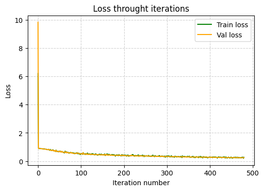

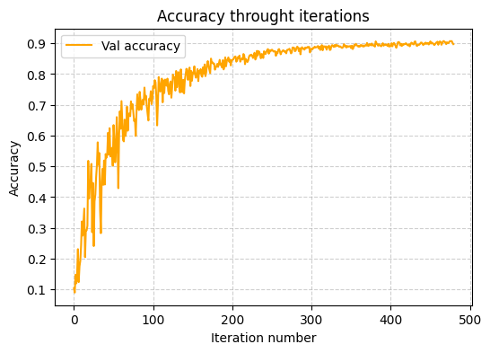

```
Final results after training:
Final train loss: 0.272, final val loss: 0.257
final val accuracy: 0.897
```

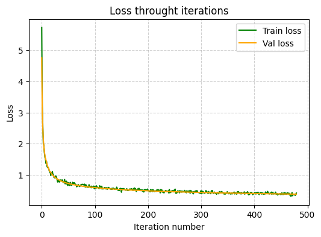

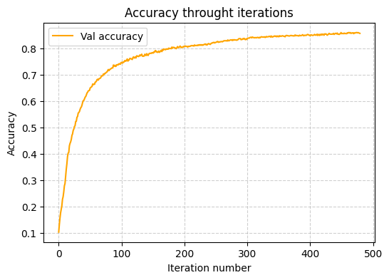

```
Final results after training:
Final train loss: 0.415, final val loss: 0.379
final val accuracy: 0.857
```

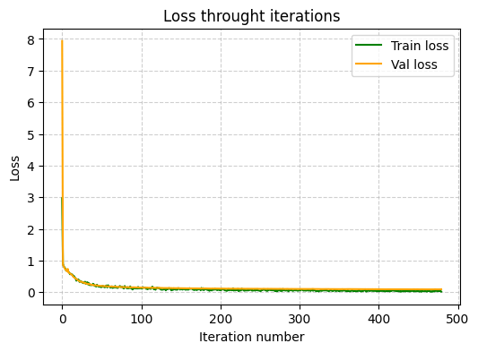

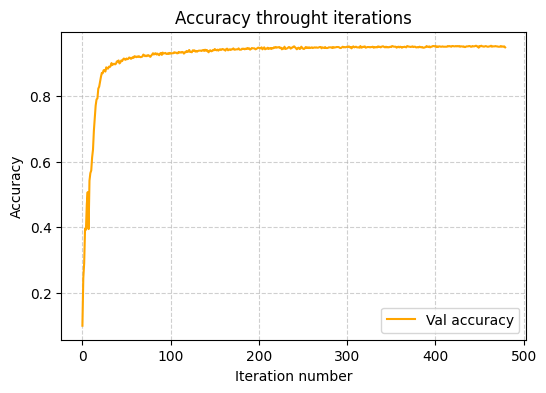

```
Final results after training:
Final train loss: 0.022, final val loss: 0.097
final val accuracy: 0.949
```

```python
# Now we test different non-linearities

batch_size = 120
epochs = 60

lr = 1e-2*9
model = DeepMLP([128,128,32],Sigmoid) #Bst 128,128,32
train_losses, val_losses, val_accuracies = train(model, loss, train_data, train_labels, val_data, val_labels, lr, batch_size, epochs)

lr = 1e-3
model = DeepMLP([128,128,32],Tanh) #Bst 128,128,32
train_losses, val_losses, val_accuracies = train(model, loss, train_data, train_labels, val_data, val_labels, lr, batch_size, epochs)

lr = 1e-2*7
model = DeepMLP([128,128,32],LeakyReLU) #Bst 128,128,32
train_losses, val_losses, val_accuracies = train(model, loss, train_data, train_labels, val_data, val_labels, lr, batch_size, epochs)
```

```python
# We test Leaky ReLU on the test set

test_loss, test_accuracy = evaluate(model, loss, test_data, test_labels)
print(f'Test loss {test_loss}, accuracy {test_accuracy}')
```

```
Test loss 0.13531467529127975, accuracy 0.9235
```

Interpretation :

The Tanh and Sigmoid functions do not lead to better results, which confirms the effectiveness (as discussed in the lecture) of the ReLU function. The LeakyReLU is close to the performances of the ReLU but doesn't improve accuracy.

**Q11.** Implement and test different loss functions (L1, Cross-Entropy)

```python
# We define other loss functions class

class L1(Module):
    """
    This implementation of the L1 loss assumes that the data comes as a 2-dimensional array
    of size (batch_size, num_classes) and the labels as a vector of size (batch_size)
    """
    def __init__(self, num_classes=10):
        super(L1, self).__init__()
        self.num_classes = num_classes

    def make_target(self, x, labels):
        target = np.zeros([x.shape[0], self.num_classes])
        for i in range(x.shape[0]):
            target[i, labels[i]] = 1

        return target

    def forward(self, x, labels):
        target = self.make_target(x, labels)
        self.output = np.sum(np.abs(target-x), axis=1)
        return np.mean(self.output)

    def backward(self, x, labels):
        target = self.make_target(x, labels)
        self.gradInput = np.sign(x - target) / x.shape[0]
        return self.gradInput

class Cross_Entropy(Module):
    """
    This implementation of the Cross_Entropy loss assumes that the data comes as a 2-dimensional array
    of size (batch_size, num_classes) and the labels as a vector of size (batch_size)
    """
    def __init__(self, num_classes=10):
        super(Cross_Entropy, self).__init__()
        self.num_classes = num_classes

    def make_target(self, x, labels):
        target = np.zeros([x.shape[0], self.num_classes])
        for i in range(x.shape[0]):
            target[i, labels[i]] = 1
        return target

    def softmax(self, x): # Softmax function to convert logits to probabilities
        exp_x = np.exp(x - np.max(x, axis=1, keepdims=True))
        return exp_x / np.sum(exp_x, axis=1, keepdims=True)

    def forward(self, x, labels):
        probs = self.softmax(x)
        target = self.make_target(x, labels)
        self.output = -np.sum(target * np.log(probs + 1e-9), axis=1) # We add a small value to avoid log(0)
        return np.mean(self.output)

    def backward(self, x, labels):
        probs = self.softmax(x)
        target = self.make_target(x, labels)
        self.gradInput = (probs - target) / x.shape[0]
        return self.gradInput
```

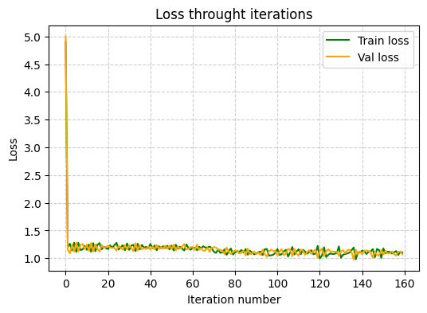

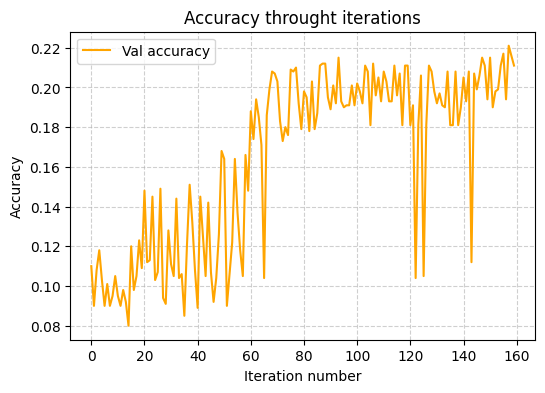

```
Final results after training:
Final train loss: 1.102, final val loss: 1.069
final val accuracy: 0.211
```

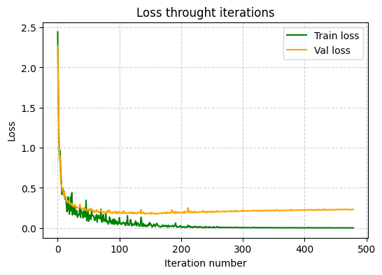

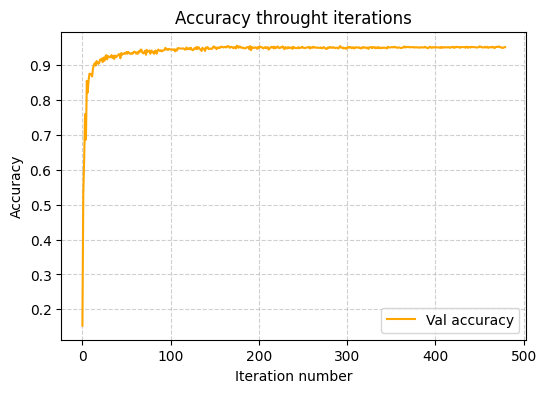

```
Final results after training:
Final train loss: 0.002, final val loss: 0.233
final val accuracy: 0.952
```

```python
#Then we can test those different loss functions

lr = 1e-2*5
batch_size = 120
epochs = 20
loss = L1()
model = DeepMLP([128,128,32])
train_losses, val_losses, val_accuracies = train(model, loss, train_data, train_labels, val_data, val_labels, lr, batch_size, epochs)

lr = 1e-2*8
batch_size = 120
epochs = 60
loss = Cross_Entropy()
model = DeepMLP([128,128,32])
train_losses, val_losses, val_accuracies = train(model, loss, train_data, train_labels, val_data, val_labels, lr, batch_size, epochs)
```

```python
# We test Cross Entropy on the test set

test_loss, test_accuracy = evaluate(model, loss, test_data, test_labels)
print(f'Test loss {test_loss}, accuracy {test_accuracy}')
```

```
Test loss 0.30295402147426753, accuracy 0.9325
```

The L1 loss gives very poor results, which can be explained by the fact that its derivative can only take the value +-1. As a result, it is very difficult to converge to any minimum because it cannot adapt the step size. In practice a good loss should produce smaller gradient near a minimum, and on the contrary, produce bigger steps when it is far from any optimal solution.

The Cross-Entropy Loss is more effective. It uses the Softmax function to normalize the predictions under the form of a probability distribution over the classes. To implement this loss (and especially the Softmax normalization), I used online ressources on internet, mostly this kaggle tutorial : https://www.kaggle.com/code/dhadheechi/mnist-using-fast-ai-and-cross-entropy-function.  
This loss, penalizes a lot confident but wrong predictions, which usualy leads to better results on classification problems. However,here, the results obtained with Cross-Entropy are slightly worse than those with MSE(). We can also observe from the loss evolution that the convergence with this loss is faster

**Q12.** Add some momentum to your training procedure. How does it change the training behavior?

```python
# We modify the Linear class to add momentum in gradient step

class Linear(Module):
    """
    Fully-connected (dense) layer with momentum-based gradient updates.
    Input shape:  (batch_size, in_features)
    Output shape: (batch_size, out_features)
    """
    def __init__(self, in_features, out_features, bias=True):
        super(Linear, self).__init__()
        self.in_features = in_features
        self.out_features = out_features

        std = math.sqrt(2 / in_features)
        self.weight = std * np.random.randn(out_features, in_features)
        self.bias = np.zeros(out_features)

        self.delta_w = np.zeros_like(self.weight) # Momentum term for weights
        self.delta_b = np.zeros_like(self.bias) # Momentum term for biases

    def forward(self, x):
        """
        Compute the forward pass: output = x * W^T + b
        """
        self.output = np.dot(x, self.weight.T) + self.bias[None, :]
        return self.output

    def backward(self, x, gradOutput):
        """
        Compute gradients for backpropagation.
        """
        self.gradInput = np.dot(gradOutput, self.weight)
        self.gradWeight = np.dot(gradOutput.T, x)
        self.gradBias = np.sum(gradOutput, axis=0)
        return self.gradInput

    def gradientStep(self, lr, momentum=0.8):  # Added momentum parameter
        """
        Gradient update with momentum:
        """
        self.delta_w = momentum * self.delta_w + (1 - momentum) * self.gradWeight # Update momentum term for weights
        self.delta_b = momentum * self.delta_b + (1 - momentum) * self.gradBias # Update momentum term for biases

        self.weight -= lr * self.delta_w
        self.bias   -= lr * self.delta_b


#Most of previous functions need to be modified to include momentum

# We modify the training functions to include momentum

def train_iter(model, loss, batch_data, batch_labels, lr, momentum): # Added momentum parameter
    """Performs one training iteration on a batch."""
    predictions = model.forward(batch_data)
    loss_value = loss.forward(predictions, batch_labels)
    gradient = loss.backward(predictions, batch_labels)
    model.backward(batch_data, gradient)
    model.gradientStep(lr, momentum) # Added momentum parameter
    return loss_value


def train_epoch(model, loss, data, labels, val_data, val_labels, lr, momentum, batch_size): # Added momentum parameter
    """Trains the model for one epoch and evaluates every 10 iterations."""
    train_losses = []
    val_losses = []
    val_accuracies = []

    indices = np.arange(len(data))
    np.random.shuffle(indices)
    data = data[indices]
    labels = labels[indices]

    for i in range(len(data) // batch_size):
        batch_data = data[i * batch_size:(i + 1) * batch_size]
        batch_labels = labels[i * batch_size:(i + 1) * batch_size]

        loss_value = train_iter(model, loss, batch_data, batch_labels, lr, momentum) # Added momentum parameter

        if i % 10 == 0:
            val_loss, val_accuracy = evaluate(model, loss, val_data, val_labels)

            train_losses.append(loss_value)
            val_losses.append(val_loss)
            val_accuracies.append(val_accuracy)

    return train_losses, val_losses, val_accuracies


def train(model, loss, train_data, train_labels, val_data, val_labels, lr, momentum, batch_size, epochs): # Added momentum parameter
    """Trains the model for multiple epochs and plots the results."""
    train_losses = []
    val_losses = []
    val_accuracies = []

    for epoch in range(epochs):
        train_epoch_losses, val_epoch_losses, val_epoch_accuracies = train_epoch(
            model, loss, train_data, train_labels, val_data, val_labels, lr, momentum, batch_size # Added momentum parameter
        )
        train_losses.extend(train_epoch_losses)
        val_losses.extend(val_epoch_losses)
        val_accuracies.extend(val_epoch_accuracies)

    plt.figure(figsize=(6, 4))
    plt.plot(range(len(train_losses)), train_losses, label='Train loss')
    plt.plot(range(len(val_losses)), val_losses, label='Val loss')
    plt.xlabel('Iteration number')
    plt.ylabel('Loss')
    plt.title('Loss through iterations')
    plt.legend()
    plt.grid(True, linestyle='--', alpha=0.6)
    plt.show()

    plt.figure(figsize=(6, 4))
    plt.plot(range(len(val_accuracies)), val_accuracies,color ='orange', label='Val accuracy')
    plt.xlabel('Iteration number')
    plt.ylabel('Accuracy')
    plt.title('Accuracy through iterations')
    plt.legend()
    plt.grid(True, linestyle='--', alpha=0.6)
    plt.show()

    print('Final results after training:')
    print(f'Final train loss: {train_losses[-1]:.3f}, final val loss: {val_losses[-1]:.3f}')
    print(f'Final val accuracy: {val_accuracies[-1]:.3f}')

    return train_losses, val_losses, val_accuracies

# Finally we modify the DeepMLP class to include momentum

class DeepMLP (Module):
    """
    This class is a simple example of a neural network, composed of
    linear layers, with a non-linearity function
    """
    def __init__(self, hidden_features,non_linearity_function=ReLU, in_dimension=784, num_classes=10):
        super(DeepMLP, self).__init__()
        self.layers = []
        self.activations = []
        self.non_linearity_function = non_linearity_function

        prev_dim = in_dimension
        for h in hidden_features:
            self.layers.append(Linear(prev_dim, h))
            self.activations.append(self.non_linearity_function())
            prev_dim = h

        self.layers.append(Linear(prev_dim, num_classes))

    def forward(self, x):
            self.inputs = [x]
            for i in range(len(self.layers)):
                x = self.layers[i].forward(x)
                if i < len(self.activations):
                    x = self.activations[i].forward(x)
                self.inputs.append(x)
            return x

    def backward(self, x, gradient):
        for i in range(len(self.layers) - 1, -1, -1):
            if i < len(self.activations):
                gradient = self.activations[i].backward(self.layers[i].output, gradient)
            gradient = self.layers[i].backward(
                self.inputs[i], gradient
            )
        return gradient

    def gradientStep(self, lr, momentum): # Added momentum parameter
        for i in range(len(self.layers)):
            self.layers[i].gradientStep(lr,momentum) # Added momentum parameter
```

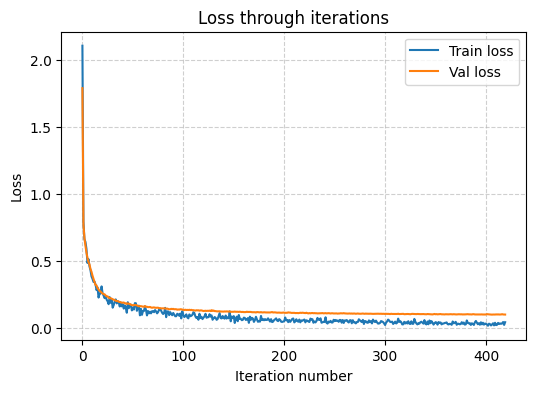

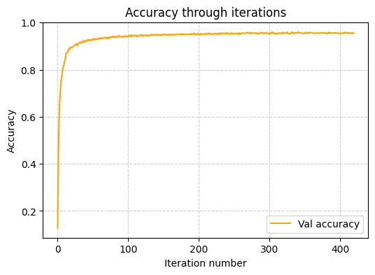

```
Final results after training:
Final train loss: 0.044, final val loss: 0.101
Final val accuracy: 0.956
```

```python
# We can now train our model with momentum

model = DeepMLP([128,128,32])
loss = MSE()
lr = 1e-1
batch_size = 130
epochs = 60
momentum = 0.70
train_losses, val_losses, val_accuracies = train(model, loss, train_data, train_labels, val_data, val_labels, lr, momentum, batch_size, epochs)
```

```python
# We test momentum on the test set

test_loss, test_accuracy = evaluate(model, loss, test_data, test_labels)
print(f'Test loss {test_loss}, accuracy {test_accuracy}')
```

```
Test loss 0.13320566637462325, accuracy 0.935
```

In practice, the results with and without momentum are very similar